# AdityaKunapuli_HW6

Aditya Kunapuli

November 17, 2018

# Part I - Gambler’s Ruin

Suppose you have a bankroll of $1000 and make bets of $100 on a fair game. By simulating the outcome directly for at most 5000 iterations of the game (or hands), estimate the following. (You must stop playing if your player has gone bust.) a. the probability that you have “busted” (lost all your money) by the time you have placed your one hundredth bet. b. the probability that you have busted by the time you have placed your five hundredth bet by simulating the outcome directly. c. the mean time you go bust, given that you go bust within the first 5000 hands. d. the mean and variance of your bankroll after 100 hands (including busts). e. the mean and variance of your bankroll after 500 hands (including busts). 2. Repeat the previous problem with betting on black in American roulette, where the probability of winning on any spin is 18/38 for an even payout. 3. For the American roulette problem in the previous question, you calculated a mean value. Because you saved these final results in a vector, use the bootstrap to estimate the variance of the return in each case for your final answer.

```r
GambRn <- function(iter, bankroll, bet, pWin, stopVal=5000)
{
  beginTime <- proc.time()
  br <- foreach(i=1:iter, .combine=rbind) %dopar%
    {
    brTemp <- data.frame(matrix(ncol = 4, nrow = 0))
    timestep <- 0
    funds <- bankroll
    while(timestep != stopVal)
    {
      if(funds < bet){break}
      timestep <- timestep + 1
      rnd <- runif(1)
      if(rnd <= pWin)
        {funds <- (funds + bet)}
      else
        {funds <- (funds - bet)}
      brTemp[timestep,] <- c(i, timestep, rnd, funds)
    }
    brTemp
  }
  cat("Time Elapsed =",((proc.time() - beginTime)[[3]]),"\n")
  cat("Rows/Sec =", round(nrow(br)/(proc.time() - beginTime)[[3]]))
  return(br)
}
```

```r
grList1 <- data.frame(matrix(ncol = 4, nrow = 0))
grList1 <- GambRn(5000, 1000, 100, 0.5, 5000)
```

```
## Time Elapsed = 331.24
## Rows/Sec = 15584
```

```r
colnames(grList1) <- c("iter","betNum","rand","bankroll")
```

# 1a

```r
sum(aggregate(betNum ~ iter, grList1, max)$betNum<=100)/5000
```

```
## [1] 0.3142
```

# 1b

```r
sum(aggregate(betNum ~ iter, grList1, max)$betNum<=500)/5000
```

```
## [1] 0.656
```

# 1c

```r
df <- sqldf("
SELECT A.iter, A.betNum, B.bankroll
FROM
  (SELECT iter, MAX(betNum) AS betNum FROM grList1 GROUP BY iter) AS A
INNER JOIN grList1 AS B
  ON A.iter=B.iter AND A.betNum = B.betNum
WHERE B.bankroll = 0")

mean(df$betNum)
```

```
## [1] 534.0162
```

```r
br100 <- subset(grList1, betNum>=100)$bankroll
br500 <- subset(grList1, betNum>=500)$bankroll
```

# 1d

```r
mean(br100)
```

```
## [1] 5036.386
```

```r
var(br100)
```

```
## [1] 11941684
```

# 1e

```r
mean(br500)
```

```
## [1] 5719.4
```

```r
var(br500)
```

```
## [1] 12021205
```

# 2

```r
# suppressWarnings(closeAllConnections())
# registerDoParallel(makeCluster(detectCores()))
grList2 <- data.frame(matrix(ncol = 4, nrow = 0))
iMax <- 5000
grList2 <- GambRn(5000, 1000, 100, (18/38),iMax)
```

```
## Time Elapsed = 37.58
## Rows/Sec = 25472
```

```r
colnames(grList2) <- c("iter","betNum","rand","bankroll")
```

# 2a

```r
sum(aggregate(betNum ~ iter, grList2, max)$betNum<=100)/iMax
```

```
## [1] 0.5092
```

# 2b

```r
sum(aggregate(betNum ~ iter, grList2, max)$betNum<=500)/iMax
```

```
## [1] 0.9164
```

# 2c

```r
df <- sqldf("
SELECT A.iter, A.betNum, B.bankroll
FROM
  (SELECT iter, MAX(betNum) AS betNum FROM grList2 GROUP BY iter) AS A
INNER JOIN grList2 AS B
  ON A.iter=B.iter AND A.betNum = B.betNum
WHERE B.bankroll = 0")

mean(df$betNum)
```

```
## [1] 191.4472
```

# 2d

```r
br100 <- subset(grList2, betNum>=100)$bankroll
br500 <- subset(grList2, betNum>=500)$bankroll
```

```r
mean(br100)
```

```
## [1] 1766.179
```

```r
var(br100)
```

```
## [1] 1356198
```

# 2e

```r
mean(br500)
```

```
## [1] 2356.59
```

```r
var(br500)
```

```
## [1] 2158865
```

# 3 First method uses `boot` library. Second method is my own.

```r
library(boot)
meanF <- function(d, i) {return(mean(d[i], na.rm=T))}
bootF <- function(d) {boot(d, meanF, R = 10000) }

b100 <- lapply(data.frame(br100), function(x) bootF(x) )
lapply(data.frame(br500), function(x) bootF(x) )
```

[output not shown]

```r
meanbr100Temp <- numeric(length(br100))
meanbr500Temp <- numeric(length(br500))
varbr100Temp <- numeric(length(br100))
varbr500Temp <- numeric(length(br500))

for(i in 1:length(br100))
{
  meanbr100Temp[i] <- mean(sample(br100,replace=T, size=500))
  varbr100Temp[i] <- var(sample(br100,replace=T, size=500))
}
for(i in 1:length(br500))
{
  meanbr500Temp[i] <- mean(sample(br500,replace=T, size=5000))
  varbr500Temp[i] <- var(sample(br500,replace=T, size=5000))
}
cat("Mean of bankroll after 100 bets =", mean(meanbr100Temp), "\n")
```

```
## Mean of bankroll after 100 bets = 1766.175
```

```r
cat("Variance of bankroll after 100 bets =", var(varbr100Temp), "\n\n")
```

```
## Variance of bankroll after 100 bets = 17464429942
```

```r
cat("Mean of bankroll after 500 bets =", mean(meanbr500Temp),"\n")
```

```
## Mean of bankroll after 500 bets = 2356.619
```

```r
cat("Variance of bankroll after 500 bets =", var(varbr500Temp))
```

```
## Variance of bankroll after 500 bets = 2956766022
```

# Part II - Elo Ratings

# 4 - Create a “true” vector of ratings for 13 players whose ratings range from -2 to 2 in even intervals.Create another vector with the current ratings which will be updated on a game-by-game basis, and a matrix with 13 rows and 10,000 columns into which we will deposit the ratings over time.

```r
v1 <- as.numeric(sample(-2:2, 13, replace=T))
v2 <- v1
m <- matrix(ncol = 13, nrow = 10000)
v1
```

```
##  [1] -1  1  1 -2  1  0 -2  0  1  1  2  0  2
```

```r
# m[1,] <- v1
# head(m,10)
```

# 5 - Write a function that simulates a game between players i and j given their true underlying ratings. This should be a simple draw from rbinom(1,1,p) with the appropriate probability.

```r
winProbP1 <- function(p1, p2)
{
  R1 <- v1[p1]
  R2 <- v1[p2]
  return(1/(1 + exp(R2 - R1)))
}

winGameP1 <- function(p1, p2)
{
  p <- winProbP1(p1, p2)
  return(rbinom(1, 1, p))
}
```

# 6 - Write a function that, given a value of K, replaces the ratings for the two players who just played a game with their updated ratings given the result from the previous question.

```r
playGame <- function(p1, p2, k=1)
{
  if(winGameP1(p1,p2)==1)
  {
    v2[p1] <<- v2[p1] + k * (1 - winProbP1(p1,p2))
    # v2[p2] <<- v2[p2] - k * winProbP1(p1,p2)
  }
  else
  {
    v2[p1] <<- v2[p1] - k * winProbP1(p1,p2)
    # v2[p2] <<- v2[p2] + k * (1 - winProbP1(p1,p2))
  }
}
v1
```

```
##  [1] -1  1  1 -2  1  0 -2  0  1  1  2  0  2
```

```r
playGame(1, 2)
v2
```

```
##  [1] -1.119203  1.000000  1.000000 -2.000000  1.000000  0.000000 -2.000000
##  [8]  0.000000  1.000000  1.000000  2.000000  0.000000  2.000000
```

# 7 - Write a function that selects two players at random from the 13, makes them play a game according to their true ratings, and updates their observed ratings.

```r
gameTime <- function(k=1)
{
  players <- sample(1:13, 2, replace=FALSE)
  playGame(players[1], players[2], k)
}
```

# 8 - Finally, write a function that simulates a tournament as prescribed above: 10,000 games should be played between randomly chosen opponents, and the updated ratings should be saved in your rating matrix by iteration.

```r
simTour <- function(k=1)
{
  # v2 <<- v1
  for(i in 1:10000)
  {
    m[i,] <<- v2
    gameTime(k)
  }
}
```

# 9 - Run this tournament with K = 0.01. Plot the rating for the best player over time using plot(…,ty=“l”); add the rating for the worst player using lines(…). Do they appear to converge to the true ratings?

### The player’s rankings don’t seem to change much with `k=0.01`

```r
v2 <- v1
simTour(k=0.01)
avgRankdf <- data.frame(matrix(ncol = 2, nrow = 13))

for(i in 1:ncol(m))
{
  avgRankdf[i,1] <- i
  avgRankdf[i,2] <- mean(m[,i])
}

bestPlayer <- avgRankdf[avgRankdf[2]==max(avgRankdf[2]),][[1]]
bestRank <- max(m[,bestPlayer])
# bestRank <- avgRankdf[avgRankdf[2]==max(avgRankdf[2]),][[2]]
cat("Best Player =", bestPlayer, " Rank =", bestRank, "\n")
```

```
## Best Player = 11  Rank = 2.061261
```

```r
worstPlayer <- avgRankdf[avgRankdf[2]==min(avgRankdf[2]),][[1]]
worstRank <- min(m[,worstPlayer])
cat("Worst Player =", worstPlayer, " Rank =", worstRank)
```

```
## Worst Player = 4  Rank = -2.034898
```

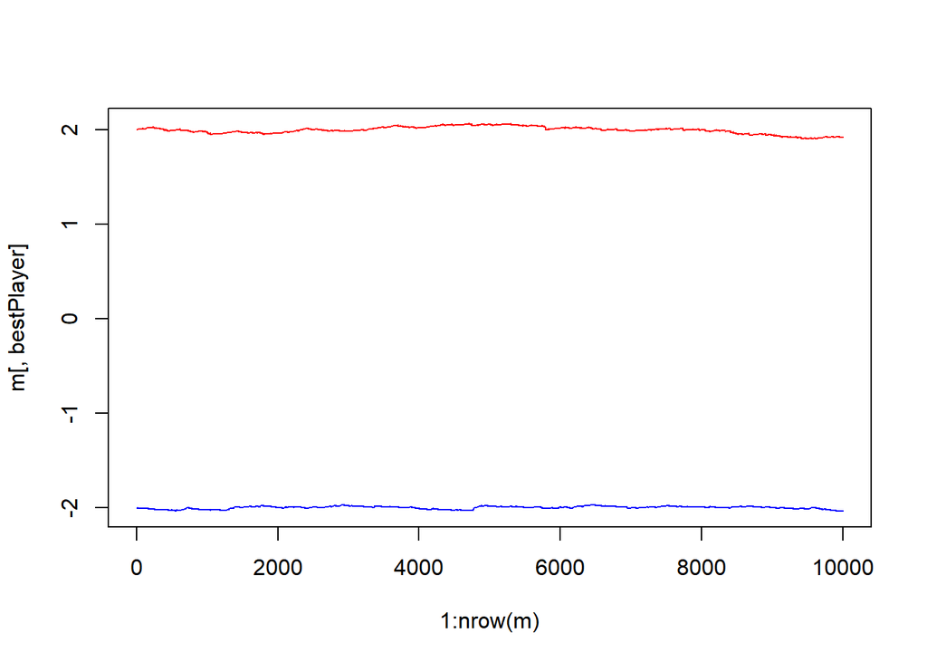

```r
plot(x = 1:nrow(m), y = m[,bestPlayer], ty="l", ylim = c(worstRank, bestRank), col="red")
lines(1:nrow(m), m[,worstPlayer], col="blue")
```

# 10 - Repeat the previous step with K equal to 0.03, 0.06, 0.1, 0.3, 0.6 and 1. Which appears to give the most reliable rating results?

```
##  Best Player = 11  Rank = 2.370681
## Worst Player = 7  Rank = -2.411855
```

```
##  Best Player = 11  Rank = 2.65692
## Worst Player = 7  Rank = -2.427772
```

```
##  Best Player = 11  Rank = 2.699748
## Worst Player = 1  Rank = -3.536498
```

```
##  Best Player = 13  Rank = 4.031204
## Worst Player = 7  Rank = -4.871788
```

```
##  Best Player = 13  Rank = 12.9445
## Worst Player = 11  Rank = -16.58782
```

```
##  Best Player = 13  Rank = 27.66012
## Worst Player = 10  Rank = -29.10891
```

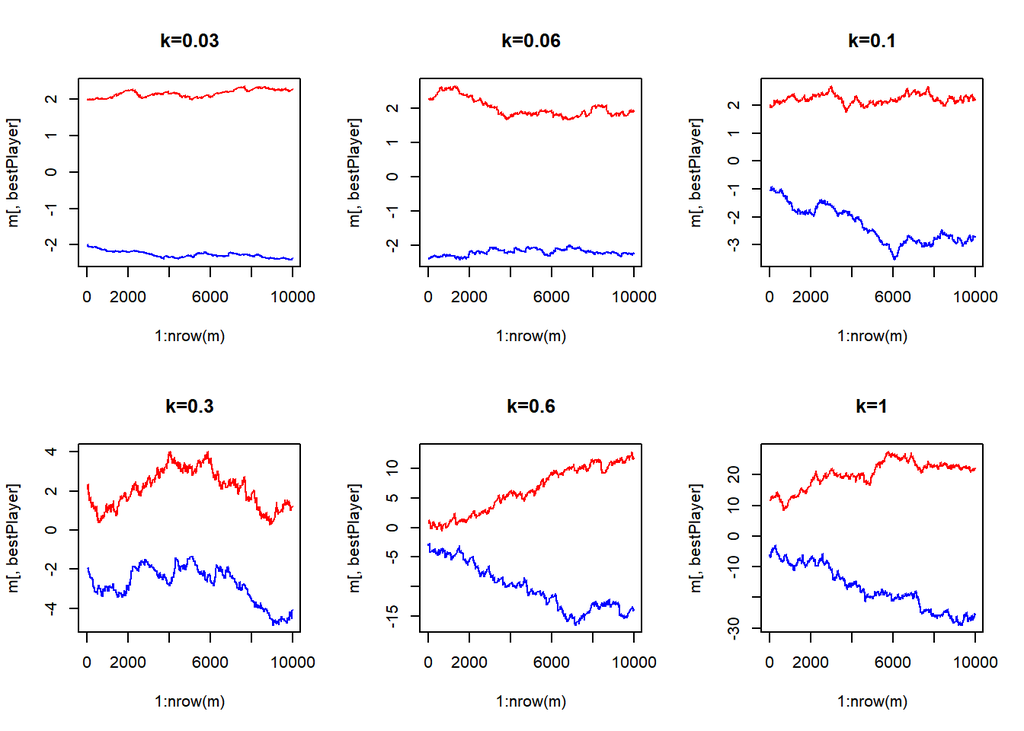

```r
v2 <- v1
kVals <- c(0.03, 0.06, 0.1, 0.3, 0.6, 1)
par(mfrow=c(2,3))
for (kk in kVals)
{
  simTour(k=kk)
  avgRankdf <- data.frame(matrix(ncol = 2, nrow = 13))

  for(i in 1:ncol(m))
  {
  avgRankdf[i,1] <- i
  avgRankdf[i,2] <- mean(m[,i])
  }

  bestPlayer <- avgRankdf[avgRankdf[2]==max(avgRankdf[2]),][[1]]
  bestRank <- max(m[,bestPlayer])
  # bestRank <- avgRankdf[avgRankdf[2]==max(avgRankdf[2]),][[2]]
  cat(" Best Player =", bestPlayer, " Rank =", bestRank, "\n")

  worstPlayer <- avgRankdf[avgRankdf[2]==min(avgRankdf[2]),][[1]]
  worstRank <- min(m[,worstPlayer])
  cat("Worst Player =", worstPlayer, " Rank =", worstRank)

  plot(x = 1:nrow(m), y = m[,bestPlayer], ty="l", ylim = c(worstRank, bestRank), col="red", main=(paste0("k=",kk)))
  lines(1:nrow(m), m[,worstPlayer], col="blue")
}
```